# General Tasks Group 40

To run the code, make sure to update the `DATA_PATH` variable to match the location of your data files on your system.

```python
from pathlib import Path
import os

# Try multiple possible data locations
possible_paths = [
    Path("data"),  # data folder in current directory
  ]

# Find the first path that exists
DATA_PATH = None
for path in possible_paths:
    if path.exists():
        DATA_PATH = path
        print(f"Found data at: {DATA_PATH}")
        break

if DATA_PATH is None:
    print("Data folder not found. Please ensure your data is in one of these locations:")
    for path in possible_paths:
        print(f"  - {path.absolute()}")
    raise FileNotFoundError("Data folder not found")
```

```
Found data at: data
```

### a) How is the logistics delay distributed? Justify your choice with statistical tests and briefly describe your approach. (2 points)

Normality was tested using the Shapiro–Wilk and Kolmogorov–Smirnov tests. In both cases, the null hypothesis of normality was rejected (p < 0.05).

**Conclusion.**  
The logistics delay is not normally distributed. Although it is tightly concentrated around 6 days with low dispersion, the data shows slight right skewness and heavier tails, causing it to deviate from a Normal distribution.

References [https://www.geeksforgeeks.org/data-science/difference-between-skewness-and-kurtosis/]

[https://www.geeksforgeeks.org/data-science/normality-test/]

```
Komponente head:
        IDNummer Produktionsdatum  Herstellernummer  Werksnummer  Fehlerhaft
1  K7-114-1142-1       2008-11-12               114         1142           0
2  K7-114-1142-2       2008-11-12               114         1142           0
3  K7-114-1142-3       2008-11-13               114         1142           0
4  K7-114-1142-4       2008-11-13               114         1142           0
5  K7-114-1142-5       2008-11-13               114         1142           0

Logistik head:
             IDNummer Wareneingang  Herstellernummer  Werksnummer  Fehlerhaft
1  K7-113-1132-153160   2016-11-22               112         1132           0
2  K7-113-1132-153109   2016-11-20               112         1132           0
3  K7-113-1132-153195   2016-11-20               112         1132           0
4  K7-113-1132-153226   2016-11-20               112         1132           0
5  K7-113-1132-153231   2016-11-20               112         1132           0
count    306490.000000
mean          6.080437
std           1.012302
min           3.000000
25%           5.000000
50%           6.000000
75%           7.000000
max          14.000000
Name: Logistics_Delay, dtype: float64
Mode: 6
Variance: 1.0247545510241098
IQR: 2.0
Skewness: 0.5674067497996634 (>0 = right-skewed, <0 = left-skewed)
Kurtosis: 0.6300548717524195 (0 ~ Normal tails, >0 = heavy tails, <0 = light tails)
```

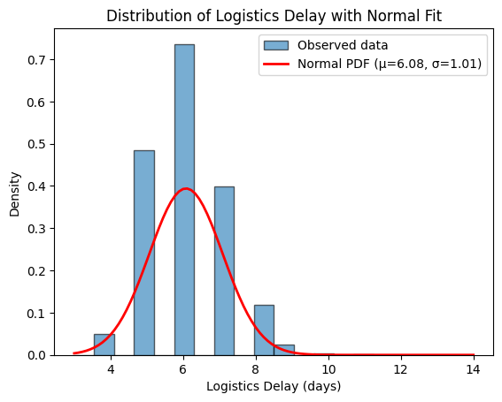

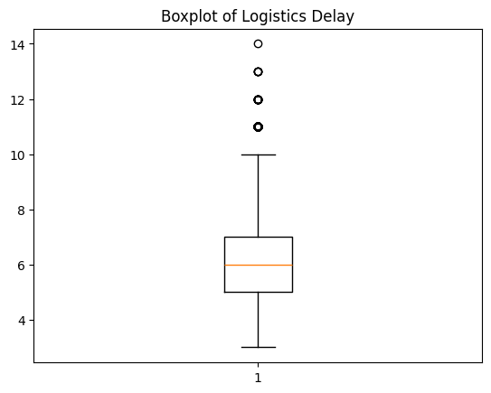

```
--- Normality Tests ---
Shapiro-Wilk test: stat=0.899, p=2.590e-49
Kolmogorov–Smirnov test: stat=0.231, p=0.000e+00
```

```python
import pandas as pd
import numpy as np
from datetime import timedelta
from scipy import stats
import matplotlib.pyplot as plt

# Step 1: Load datasets
komponente = pd.read_csv(
    DATA_PATH / "Logistikverzug" / "Komponente_K7.csv",
    sep=";",
    index_col=0
)

logistik = pd.read_csv(
    DATA_PATH / "Logistikverzug" / "Logistikverzug_K7.csv",

    index_col=0
)


print("Komponente head:")
print(komponente.head())
print("\nLogistik head:")
print(logistik.head())




# Step 2: Preprocessing
komponente['Produktionsdatum'] = pd.to_datetime(komponente['Produktionsdatum'])
logistik['Wareneingang'] = pd.to_datetime(logistik['Wareneingang'])

# Step 3: Create combined logistics delay dataset
logistics_delay = pd.merge(komponente[['IDNummer', 'Produktionsdatum', 'Fehlerhaft']],
                          logistik[['IDNummer', 'Wareneingang']],
                          on='IDNummer')

# Calculate delay (goods issued 1 day after production)
logistics_delay['Ausgabedatum'] = logistics_delay['Produktionsdatum'] + timedelta(days=1)
logistics_delay['Logistics_Delay'] = (
    logistics_delay['Wareneingang'] - logistics_delay['Ausgabedatum']
).dt.days

# Save dataset
logistics_delay.to_csv('Logistics_delay_dataset.csv', index=False)


# Step 4: Descriptive statistics (central tendency, dispersion & shape) ===
delay = logistics_delay['Logistics_Delay'].dropna()

# Summary statistics: count, mean, std, quartiles, min/max
print(delay.describe())

# Additional descriptive measures
print("Mode:", delay.mode()[0])                # Most frequent value (central tendency)
print("Variance:", delay.var())                # Spread of the data
print("IQR:", delay.quantile(0.75) - delay.quantile(0.25))  # Interquartile range (dispersion)

# Shape of the distribution
print("Skewness:", delay.skew(), "(>0 = right-skewed, <0 = left-skewed)")
print("Kurtosis:", delay.kurt(), "(0 ~ Normal tails, >0 = heavy tails, <0 = light tails)")

# Step 5: Visualization of the distribution

# Calculate mean and std for Normal fit
mu, sigma = delay.mean(), delay.std()

# Histogram of observed logistics delay
plt.hist(delay, bins=20, density=True, edgecolor='black', alpha=0.6, label="Observed data")

# Overlay Normal probability density function (for comparison)
x = np.linspace(delay.min(), delay.max(), 100)
pdf = stats.norm.pdf(x, mu, sigma)
plt.plot(x, pdf, 'r-', lw=2, label=f'Normal PDF (μ={mu:.2f}, σ={sigma:.2f})')

plt.xlabel("Logistics Delay (days)")
plt.ylabel("Density")
plt.title("Distribution of Logistics Delay with Normal Fit")
plt.legend()
plt.show()

# Boxplot to visualize spread, median, and outliers
plt.boxplot(delay)
plt.title("Boxplot of Logistics Delay")
plt.show()

# Step 6: Hypothesis tests: Normality
# (Lecture: Hypothesis Testing → Null Hypothesis H0: data ~ Normal)

delay = logistics_delay['Logistics_Delay'].dropna()
mu, sigma = delay.mean(), delay.std()

print("\n--- Normality Tests ---")

# Shapiro–Wilk Test (tests H0: data is normally distributed)
# Sampling (5000) is used due to large dataset size
shapiro_stat, shapiro_p = stats.shapiro(delay.sample(5000, random_state=42))
print(f"Shapiro-Wilk test: stat={shapiro_stat:.3f}, p={shapiro_p:.3e}")

# Kolmogorov–Smirnov Test (compare standardized data to standard Normal distribution)
ks_stat, ks_p = stats.kstest(
    (delay - mu) / sigma, 'norm'
)
print(f"Kolmogorov–Smirnov test: stat={ks_stat:.3f}, p={ks_p:.3e}")

# Decision rule: if p < 0.05 → reject H0 → data is not normally distributed
```

### b) Determine the mean logistics delay, considering weekends. Interpret this number and discuss possible alternatives. (2 points)

On average, goods take **6.08 calendar days** from shipping to arrival.  
If weekends are excluded, the mean delay drops to **4.34 business days**.  
This means that **1.74 days (≈28.6%) of the observed delay** is due solely to weekends rather than actual transportation or processing.

An alternative to reporting delays in calendar days is to use business days, which provides a more realistic measure of operational performance. In practice, it can also be useful to report both values: calendar days to capture the customer perspective, and business days to evaluate internal logistics efficiency. The approach may be further refined by excluding public holidays in addition to weekends, yielding an even more accurate estimate of effective processing times.

```python
# Create a cleaned dataframe version
df_clean = logistics_delay.loc[logistics_delay.index].copy()

# Shipping date = production + 1 day
df_clean['ShippingDate'] = df_clean['Produktionsdatum'] + pd.Timedelta(days=1)

# Calendar delay
df_clean['Delay_Calendar'] = (df_clean['Wareneingang'] - df_clean['ShippingDate']).dt.days

# Business-day delay (weekends excluded)
df_clean['Delay_Business'] = [
    np.busday_count(start.date(), end.date())
    for start, end in zip(df_clean['ShippingDate'], df_clean['Wareneingang'])
]

# Means
mean_calendar = df_clean['Delay_Calendar'].mean()
mean_business = df_clean['Delay_Business'].mean()
weekend_impact_days = mean_calendar - mean_business
weekend_impact_percent = (weekend_impact_days / mean_calendar) * 100

print(f"Mean delay (calendar days): {mean_calendar:.2f}")
print(f"Mean delay (business days): {mean_business:.2f}")
print(f"Weekend impact: {weekend_impact_days:.2f} days (~{weekend_impact_percent:.1f}%)")
```

```
Mean delay (calendar days): 6.08
Mean delay (business days): 4.34
Weekend impact: 1.74 days (~28.6%)
```

### c) Visualize the distribution appropriately by displaying the histogram and density function using “plotly.” Describe how you selected the size of the bins. (2 points)

At first, we determined the number of bins using the Freedman–Diaconis rule, since it adapts the bin width to both the spread of the data (via the interquartile range) and the sample size. However, this resulted in a very large number of bins (≈186) with a very narrow width, which made the histogram appear overly spiky and difficult to interpret. Because our data represent logistics delays measured in whole days and range only between 3 and 14, we decided to replace the Freedman–Diaconis choice with 1-day bins aligned to the integer values. This approach better matches the discrete nature of the data, produces a clearer visualization, and allows for a more intuitive interpretation of the distribution.

References: [https://www.statology.org/choosing-the-optimal-bin-size-for-your-histogram/]

```python
import numpy as np
from scipy import stats
import plotly.express as px
import plotly.graph_objects as go

# data vector
delay = logistics_delay['Logistics_Delay'].dropna().to_numpy()

# Freedman–Diaconis bin width
n = delay.size
data_min, data_max = float(delay.min()), float(delay.max())
q25, q75 = np.percentile(delay, [25, 75])
iqr = q75 - q25

h = 2 * iqr * (n ** (-1/3))   # FD bin width
bins = max(int(np.ceil((data_max - data_min) / h)), 1)
bin_width = (data_max - data_min) / bins
rule_label = f"Freedman–Diaconis (bins={bins}, width≈{bin_width:.4f})"

# KDE (density function)
x_vals = np.linspace(data_min, data_max, 400)
kde = stats.gaussian_kde(delay)
kde_pdf = kde(x_vals)

# Plotly histogram + KDE
fig = px.histogram(
    x=delay,
    histnorm="probability density",
    title="Logistics Delay — Histogram with KDE"
)
fig.update_traces(
    xbins=dict(start=data_min, end=data_max, size=bin_width),
    opacity=0.6,
    name="Histogram"
)

fig.add_trace(go.Scatter(x=x_vals, y=kde_pdf, mode="lines", name="KDE"))

fig.update_layout(
    xaxis_title="Logistics Delay (days)",
    yaxis_title="Density",
    bargap=0.05,
    legend_title_text=rule_label
)

fig.show()
print(rule_label)


data_min, data_max = float(delay.min()), float(delay.max())

# KDE (probability density)
x_vals = np.linspace(data_min, data_max, 400)
kde = stats.gaussian_kde(delay)          # KDE
kde_pdf = kde(x_vals)

# 1-day bins centered on integers
start_edge = np.floor(data_min) - 0.5
end_edge   = np.ceil(data_max) + 0.5
bin_width  = 1

# histogram normalized to density
fig = px.histogram(
    x=delay,
    histnorm="probability density",
    title="Logistics Delay — Histogram with KDE",
    labels={'x': 'Logistics Delay (days)', 'y': 'Density'}
)

fig.update_traces(
    xbins=dict(start=start_edge, end=end_edge, size=bin_width),
    opacity=0.6,
    name="Histogram (density)"
)

# overlay KDE
fig.add_trace(go.Scatter(x=x_vals, y=kde_pdf, mode="lines", name="KDE"))

fig.update_layout(bargap=0.05, legend_title_text="Layers")
fig.show()
```

[output not shown]

```
Freedman–Diaconis (bins=186, width≈0.0591)
```

### d) Describe the process for creating a decision tree to classify whether thecomponent (K7) is defective (Fehlerhaft) or not. (Hint: Use visualizations.) (2 points)

The decision tree achieved 100% accuracy, but this result is misleading due to the extreme class imbalance in the dataset: out of 306,490 samples, only 6 were defective, while 306,484 were non-defective. A model that simply predicts “non-defective” for every case already achieves almost perfect accuracy, so this metric does not show that the tree has actually learned to detect defects.

This outcome was expected: with so few positive examples, the model cannot derive meaningful rules to separate defective from non-defective parts. The issue is further amplified by the fact that the dataset relies mainly on a single feature, which—combined with the imbalance—prevents the tree from discovering any useful decision boundaries.

```
Total samples: 306,490
Non-defective: 306,484 (100.0%)
Defective: 6 (0.0%)

Model Performance:
Accuracy: 0.9999782483387168
Confusion matrix:
 [[91945     0]
 [    2     0]]
              precision    recall  f1-score   support

           0      1.000     1.000     1.000     91945
           1      0.000     0.000     0.000         2

    accuracy                          1.000     91947
   macro avg      0.500     0.500     0.500     91947
weighted avg      1.000     1.000     1.000     91947
```

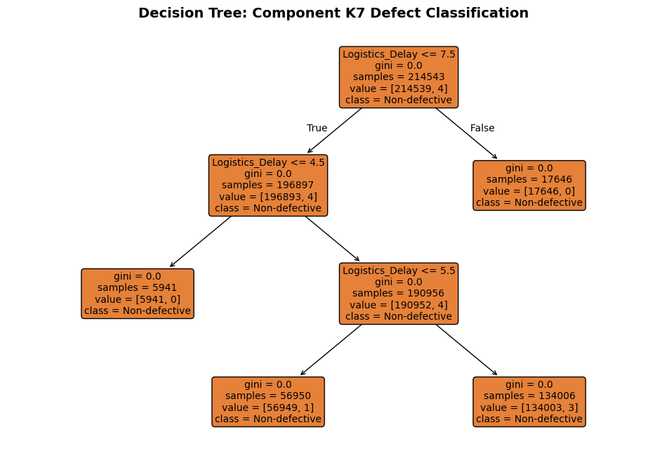

```python
from sklearn.tree import DecisionTreeClassifier, plot_tree
from sklearn.model_selection import train_test_split
from sklearn.metrics import accuracy_score, classification_report, confusion_matrix
import matplotlib.pyplot as plt

# Prepare data
df_tree = logistics_delay.loc[logistics_delay.index].copy()
X = df_tree[['Logistics_Delay']]  # Feature: logistics delay
y = df_tree['Fehlerhaft']         # Target: defect status (0/1)



print(f"Total samples: {len(df_tree):,}")
print(f"Non-defective: {sum(y==0):,} ({sum(y==0)/len(y)*100:.1f}%)")
print(f"Defective: {sum(y==1):,} ({sum(y==1)/len(y)*100:.1f}%)")

# Split data into train/test
X_train, X_test, y_train, y_test = train_test_split(
    X, y, test_size=0.3, random_state=42, stratify=y
)
# Create and train simple decision tree
tree_model = DecisionTreeClassifier(
    max_depth=3,           # Keep it simple with max 3 levels
    min_samples_split=50,  # Need at least 50 samples to split
    random_state=42
)

tree_model.fit(X_train, y_train)

# Evaluate performance
y_pred = tree_model.predict(X_test)
accuracy = accuracy_score(y_test, y_pred)

print(f"\nModel Performance:")
print("Accuracy:", accuracy_score(y_test, y_pred))
print("Confusion matrix:\n", confusion_matrix(y_test, y_pred))
print(classification_report(y_test, y_pred, digits=3))

# Visualize the decision tree
plt.figure(figsize=(12, 8))
plot_tree(tree_model,
          feature_names=['Logistics_Delay'],
          class_names=['Non-defective', 'Defective'],
          filled=True,
          rounded=True,
          fontsize=10)

plt.title("Decision Tree: Component K7 Defect Classification", fontsize=14, fontweight='bold')
plt.show()
```

## Task 2: Data Storage in Separate Files (2 Points)

**Question:** Why does it make sense to store the available data in separate files instead of saving everything in one large table?  
Name at least four benefits. What is this database structure called?

Storing data in separate files or tables rather than in one large table follows the principles of relational database design and data normalization. Each table represents a specific entity (e.g., vehicles, components, logistics, registrations) while relationships between entities are maintained through primary keys and foreign keys, as illustrated by the Entity–Relationship (ER) model in the lecture 6. This approach reduces redundancy, ensures integrity and consistency, improves performance, and increases scalability and modularity.

### Key Benefits

-Reduced Redundancy: Each fact is stored once (e.g., components linked by ID), saving space.

-Integrity & Consistency: Updates in one table propagate via keys, avoiding contradictions.

-Performance: Smaller tables allow faster queries, indexing, and optimization.

-Maintainability: changes affect only relevant tables, not the entire dataset

Additionally it enables better security (table-level access) and flexibility (different file formats:CSV, TXT, Excel).

Database structure: This is a Relational Database Schema

### Question 3 — Pipeline: Adelshofen → Vehicle Components → T16 Subparts (Auto-Detect Joins)

**Goal:** Count **T16** subparts in vehicles registered in **Adelshofen**, even if component files use different ID column names.

```python
import os
import pandas as pd

# Configuration
ZULASSUNGEN_FILE = os.path.join(DATA_PATH, "Zulassungen", "Zulassungen_alle_Fahrzeuge.csv")
FAHRZEUG_DIR     = os.path.join(DATA_PATH, "Fahrzeug")
KOMPONENTE_DIR   = os.path.join(DATA_PATH, "Komponente")

# ----------------  Adelshofen vehicles ----------------
zul = pd.read_csv(ZULASSUNGEN_FILE, sep=";", encoding="utf-8")
adel_ids = set(
    zul.loc[zul["Gemeinden"].str.contains("Adelshofen", case=False, na=False), "IDNummer"]
      .astype(str)
      .unique()
)
print(f"Vehicles in Adelshofen: {len(adel_ids):,}")

# ----------------  Vehicle → component IDs ----------------
component_types = {}

for fname in sorted(f for f in os.listdir(FAHRZEUG_DIR) if f.startswith("Bestandteile_") and f.endswith(".csv")):
    df = pd.read_csv(os.path.join(FAHRZEUG_DIR, fname), sep=";", encoding="utf-8")
    if "ID_Fahrzeug" not in df.columns:
        continue
    df["ID_Fahrzeug"] = df["ID_Fahrzeug"].astype(str)
    m = df["ID_Fahrzeug"].isin(adel_ids)
    if not m.any():
        continue

    # Collect all component ID columns for matched vehicles
    for col in df.columns:
        if col.startswith("ID_") and col != "ID_Fahrzeug":
            ids = df.loc[m, col].dropna().astype(str).unique()
            if ids.size:
                component_types.setdefault(col, set()).update(ids)
print(f"Unique component IDs (sum over types): {sum(len(s) for s in component_types.values()):,}")

# ---------------- Components → subparts (count ID_T16) ----------------
total_t16 = 0
# Collect all component IDs into a single set for simpler matching
all_component_ids = set()
for component_set in component_types.values():
    all_component_ids.update(component_set)

for fname in sorted(f for f in os.listdir(KOMPONENTE_DIR) if f.startswith("Bestandteile_Komponente_") and f.endswith(".csv")):
    df = pd.read_csv(os.path.join(KOMPONENTE_DIR, fname), sep=";", encoding="utf-8")

    if "ID_T16" not in df.columns:
        continue  # Skip files without T16 data

    # Find any ID column that matches our Adelshofen components
    mask = pd.Series(False, index=df.index)
    for col in df.columns:
        if col.startswith("ID_") and col != "ID_T16":
            col_matches = df[col].astype(str).isin(all_component_ids)
            if col_matches.any():
                mask |= col_matches
                print(f"Found {col_matches.sum()} matches in column '{col}' of {fname}")

    # Count T16 parts for matched components
    if mask.any():
        total_t16 += df.loc[mask, "ID_T16"].notna().sum()



print(f"T16 parts identified in Adelshofen vehicle components: {total_t16:,}")
```

```
Vehicles in Adelshofen: 264
Unique component IDs (sum over types): 1,056
Found 25 matches in column 'ID_K2LE2' of Bestandteile_Komponente_K2LE2.csv
Found 71 matches in column 'ID_K2ST2' of Bestandteile_Komponente_K2ST2.csv
T16 parts identified in Adelshofen vehicle components: 96
```

### 4. Attributes of the Registration Table (2 Points)

Identify the data types of the attributes in the registration table `Zulassungen_aller_Fahrzeuge`. Present the results in a table and describe the characteristics of the data types.

```python
import pandas as pd

# Load the dataset
zulassungen = pd.read_csv(
    DATA_PATH / "Zulassungen" / "Zulassungen_alle_Fahrzeuge.csv",
    sep=";",  # important because file uses ";" as separator
)

# Show column names and their data types
print("Data types of attributes in Zulassungen_alle_Fahrzeuge:")
print(zulassungen.dtypes)

zulassungen.head
```

```
Data types of attributes in Zulassungen_alle_Fahrzeuge:
Unnamed: 0     int64
IDNummer      object
Gemeinden     object
Zulassung     object
dtype: object
```

```
<bound method NDFrame.head of          Unnamed: 0        IDNummer  Gemeinden   Zulassung
0            408097       11-1-11-1    DRESDEN  2009-01-01
1            408098       11-1-11-2    DRESDEN  2009-01-01
2                 1       12-1-12-1    LEIPZIG  2009-01-01
3                 2       12-1-12-2    LEIPZIG  2009-01-01
4                 3       12-1-12-3   DORTMUND  2009-01-01
...             ...             ...        ...         ...
3204099     2895822  21-2-21-510562  WUERZBURG  2016-12-30
3204100     2897001  21-2-21-511741  WUERZBURG  2016-12-30
3204101     2895137  21-2-21-509877  WUERZBURG  2016-12-30
3204102     2896316  21-2-21-511056  WUERZBURG  2016-12-30
3204103     2897495  21-2-21-512235  WUERZBURG  2016-12-30

[3204104 rows x 4 columns]>
```

### Data Types of Attributes in `Zulassungen_alle_Fahrzeuge`

| Attribute | Data Type | Description |
| --- | --- | --- |
| `Unnamed: 0` | `int64` | Automatically generated index column (integer values). |
| `IDNummer` | `object` | Identifier stored as text; numeric but treated as string to preserve format. |
| `Gemeinden` | `object` | Municipality codes; categorical values stored as text. |
| `Zulassung` | `object` | Registration date stored as string; can be converted to `datetime`. |

## Task 5: Linear Model for Mileage (5 Points)

o Create a linear model from the table `Fahrzeuge_OEM1_Typ11_Fehleranalyse` relating mileage to suitable variables. Derive recommendations for OEM1 based on this model.

We created a linear regression model using the table `Fahrzeuge_OEM1_Typ11_Fehleranalyse`, where the dependent variable was the mileage at failure (`Fehlerhaft_Fahrleistung`). The predictors were the operational days until failure (`days`), fuel consumption (`fuel`), and the categorical variable engine, which was one-hot encoded (with large engines as the baseline).

The model achieved an (R^2) score of **0.49**, explaining about **49%** of the variance in mileage at failure, with an average prediction error (RMSE) of approximately **11,000 km**.

The model results indicate that a higher number of operational days has a small negative effect on mileage at failure (–0.079), suggesting that time-driven degradation processes such as corrosion or material aging reduce durability beyond mileage alone. In contrast, fuel consumption shows a strong positive association with mileage at failure (+5,213.6), meaning that vehicles with greater cumulative fuel usage—likely reflecting heavier or more consistent operation—tend to achieve higher mileage before failure. Regarding engine category, medium engines last on average 7,705 km longer than large engines, while small engines last approximately 10,954 km longer than large engines. This implies that large engines reach failure earlier, whereas small and medium engines generally achieve higher mileage before failure.

Based on the model results, OEM1 should prioritize improving the durability of large engines, as they reach failure earlier than medium and small engines. Maintenance schedules should consider not only mileage but also time in service, since longer operational days are linked to earlier failures. Additionally, fuel consumption proves to be a strong predictor of vehicle lifetime and should be integrated into predictive maintenance models for more accurate service planning.

```
Unnamed: 0                 0
X                          0
X1                         0
ID_Fahrzeug                0
Herstellernummer           0
Werksnummer                0
Fehlerhaft_Datum           0
Fehlerhaft_Fahrleistung    0
days                       0
fuel                       0
engine                     0
dtype: int64
Model Evaluation:
R² Score: 0.490
RMSE: 11114.10

Model Coefficients:
         Feature   Coefficient
0           days     -0.078592
1           fuel   5213.581812
2  engine_medium   7705.409026
3   engine_small  10953.705088

Intercept: 9899.64
```

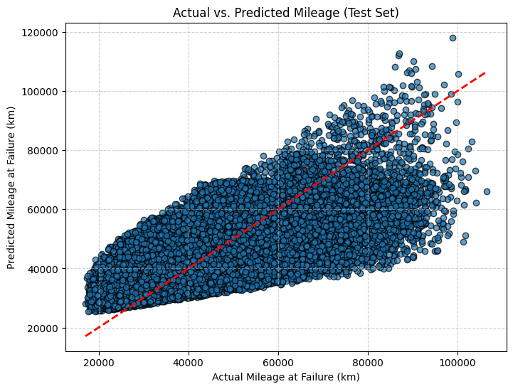

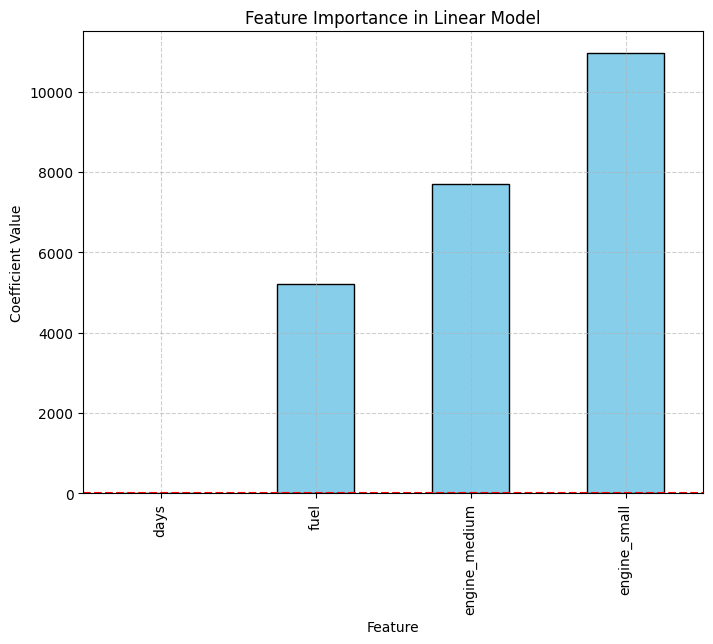

```python
# Import required libraries
import pandas as pd, numpy as np, matplotlib.pyplot as plt
from sklearn.model_selection import train_test_split
from sklearn.linear_model import LinearRegression
from sklearn.metrics import mean_squared_error, r2_score
from pathlib import Path

# Use the DATA_PATH defined earlier
df = pd.read_csv(DATA_PATH / "Fahrzeug" / "Fahrzeuge_OEM1_Typ11_Fehleranalyse.csv")
print(df.isna().sum())


# Select relevant features (predictors) and target variable
X = df[['days', 'fuel', 'engine']]                # independent variables
y = df['Fehlerhaft_Fahrleistung']                 # dependent variable (mileage at failure)

# Convert categorical variable 'engine' into dummy variables (one-hot encoding)
# drop_first=True ensures one category is used as baseline
X = pd.get_dummies(X, columns=['engine'], drop_first=True)

# Split data into training (80%) and test set (20%)
X_train, X_test, y_train, y_test = train_test_split(X, y, test_size=0.2, random_state=42)

# Fit linear regression model
model = LinearRegression().fit(X_train, y_train)

# Predict mileage values on the test set
y_pred = model.predict(X_test)

# Evaluate model performance
rmse = np.sqrt(mean_squared_error(y_test, y_pred))  # Root Mean Squared Error
r2 = r2_score(y_test, y_pred)                       # R² score
print("Model Evaluation:")
print(f"R² Score: {r2:.3f}")
print(f"RMSE: {rmse:.2f}")

# Display model coefficients for each feature
coeffs = pd.DataFrame({'Feature': X.columns, 'Coefficient': model.coef_})
print("\nModel Coefficients:")
print(coeffs)
print(f"\nIntercept: {model.intercept_:.2f}")
import matplotlib.pyplot as plt

# Actual vs Predicted Mileage
plt.figure(figsize=(8,6))
plt.scatter(y_test, y_pred, alpha=0.7, edgecolor='k')
plt.plot([y_test.min(), y_test.max()], [y_test.min(), y_test.max()], 'r--', lw=2)
plt.xlabel("Actual Mileage at Failure (km)")
plt.ylabel("Predicted Mileage at Failure (km)")
plt.title("Actual vs. Predicted Mileage (Test Set)")
plt.grid(True, linestyle='--', alpha=0.6)
plt.show()

# Feature Coefficients
plt.figure(figsize=(8,6))
coeffs.set_index('Feature').Coefficient.plot(kind='bar', color='skyblue', edgecolor='k')
plt.axhline(0, color='red', linestyle='--')
plt.ylabel("Coefficient Value")
plt.title("Feature Importance in Linear Model")
plt.grid(True, linestyle='--', alpha=0.6)
plt.show()
```

## Task 6: Hit and Run Accident Investigation (5 Points)

We searched all vehicle parts files (contained in folder `Fahrzeug`) to find the vehicle(s) that contained the target body part (K5-112-1122-79). Then we checked the registration data and filtered for registrations on or **before** the accident date (11.08.2010). Finally, we listed the latest valid registration for each matching vehicle, including the location and date, to identify possible suspects in the hit-and-run case. The investigation led to one vehicle, with the latest valid registration found in **Aschersleben on 02.01.2009**.

```python
import pandas as pd
from pathlib import Path

# Defining the target PART and DATE
PART = "K5-112-1122-79"
DATE = pd.Timestamp("2010-08-11")

# Step 1: read ALL Fahrzeug CSVs automatically
fahrzeug_path = DATA_PATH / "Fahrzeug"
parts_files = list(fahrzeug_path.glob("*.csv"))   # all CSV files in Fahrzeug/
parts = pd.concat([pd.read_csv(f, sep=";") for f in parts_files], ignore_index=True)

# Step 2: find vehicle(s) with the target body part
veh_ids = parts.loc[parts["ID_Karosserie"] == PART, "ID_Fahrzeug"].astype(str).unique()

# Step 3: check registrations
regs = pd.read_csv(DATA_PATH/"Zulassungen"/"Zulassungen_alle_Fahrzeuge.csv",
                   sep=";", encoding="utf-8", on_bad_lines="skip")
regs["Zulassung"] = pd.to_datetime(regs["Zulassung"], errors="coerce")

valid = regs[regs["IDNummer"].astype(str).isin(veh_ids) & (regs["Zulassung"] <= DATE)]
latest = valid.sort_values(["IDNummer","Zulassung"]).drop_duplicates("IDNummer", keep="last")

# Step 4: show result
if latest.empty:
    print("No valid registration found.")
else:
    for _, r in latest.iterrows():
        print(f"{r['IDNummer']} -> {r['Gemeinden']} on {r['Zulassung'].date()}")
```

```
12-1-12-82 -> ASCHERSLEBEN on 2009-01-02
```